# Bayesian linear regression for poets

*Daniel Valdenegro Ibarra \ PhD Student in Computational Social Science \ University of Leeds, UK*

In this notebook I will attempt to recreate [this](https://zjost.github.io/bayesian-linear-regression/) tutorial of Bayesian linear regression using Julia language, but with a prose and examples hopefully more relatable to a social scientist. I am helping myself by referring to [this](https://www.ncbi.nlm.nih.gov/pmc/articles/PMC2885293/) paper and to the [doctoral thesis](https://ora.ox.ac.uk/objects/uuid:bf6c3fb5-5208-4dfe-aa0a-6e6da45c0d87) of one of my excellent supervisors Richard P. Mann.

This exercise has three main objectives:

- The first is procrastination. If I'm going to waste my time I may as well waste it in some productive way.
- The second is to increase my limited understanting of Bayesian inference. I can always read some more manuals and explanations, but without some hands-on activity I will never be able to fully get it. Also, I want to share and refine this tutorial with my fellow social scientist, so we can make the knowledge of mathematical concepts more accesible, instead of keeping them under the custody of a reclusive band of nerds (myself included).
- And third, I want to learn Julia language. Julia is a relatively new programming language with a clear focus on scientific computing, with the added feature that can be compiled for performance. I'm getting fed up of Tidyverse users proclaiming their gospel, and Python 'data scientist' trying to apply deep learning to everything, and Julia looks like a nice escape from that.

Since this is a tutorial of a fairly complex mathematical algorithm, the use of mathematical expressions will be inevitable. I'm not a mathematician, and probably I don't understand these concepts enough, but I will try my best to explain them clearly. Hopefully, this effort will help me to understand Bayesian inference better, with the added bonus of communicate it to you, the reader.

# Section 1: The maths

## The Bayes law and conditional probabilities

The Bayes law is a probability theorem, so we migth benefit from reviewing some core concepts and terminology.

The probability of an event A is commonly denoted $P(A)$ and is usually defined as the number of desired outcomes, divided by the total number of all outcomes (e.g. number of heads on the total number of coin tosses).

Conditional probability of an event A given B is denoted $P(A \mid B)$ and is defined as the probability of A occuring given that B already occurred, and can be calculated as follows:

$$P(A \mid B) = \frac{P(A \cap B)}{P(B)} \tag{1}$$

The above equation can also be rearranged as follows:

$$P(A \cap B) = P(A \mid B)P(B) \tag{2}$$

Where $P(A \cap B)$ is the probability that both events A and B occur, and if A and B are independent events, its caculated $P(A)P(B)$. We must note that $P(A \mid B)$ is not equal to $P(B \mid A)$.

However, we do know that:

$$P(A \cap B) = P(B \cap A) \tag{3}$$

Meaning that the joint propability of A and B is the same as the joint probability of B and A, because of the commutative property of multiplication. Now, taken equation (2) and (3) into consideration we can also say that:

$$P(A \mid B)P(B) = P(B \mid A)P(A) \tag{4}$$

And if we rearrange equation (4) to leave only one term in th left side we arrive to the Bayes law, which describes the relationship between $P(A \mid B)$ and $P(B \mid A)$.

$$P(A \mid B) = \frac{P(B \mid A)P(A)}{P(B)} \tag{5}$$

## Bayes in linear regression

### Setting up the stage

Now, lets try to use the Bayes law, described in equation (5), to device a way to estimate the parameters of a simple linear regression. Lets first recall the parts and the general form of a simple linear regression:

$$y_{i}=w_{0}+w_{1}x_{i}+\epsilon_{i} \quad i = 1,\cdots, n \tag{6}$$

In equation (6), $y_i$ is the value of the $ith$ element of the outcome variable $\mathbf{y}$ we are trying to model.The $x_i$ is the $ith$ element of the variable $\mathbf{x}$ we use to describe $\mathbf{y}$ and is generally known as the predictor. The set of parameters $\{w_{0}, w_{1}, \epsilon_i\}$ are commonly called the intercept, the slope and the error, respectively. For simplicity, these parameters can be gruped into *weights* (intercept and slope), and noise (or error). These are unknown, and we hope to estimate them from the data. The data is composed by the column vectors (always in bold) $\mathbf{x} = \langle x_{1}, x_{2}, \dots, x_{n}\rangle$ and $\mathbf{y} = \langle y_{1}, y_{2}, \dots, y_{n}\rangle$. It is also very common to have multiple predictors in a linear regresion. If those are grouped together into a matrix $\mathbf{X}$ and we group our *weights* into a column vector $\mathbf{w}$ and the noise into the scalar $\mathbf{\epsilon}$, we can use matrix notation to have a more general form for our linear regression model:

$$\mathbf{y} = \mathbf{w}\mathbf{X} + \mathbf{\epsilon} \tag{7}$$

From a traditional frequentist stand point, the goal of the estimation process is to get a "point estimate". This means to get a single value for each parameter. Now, from a Bayesian stand point this is not acceptable, because we don't want only the probability of obtaining a single particular value. We want a way to estimate the probability of obtaining *any* value the parameters can take (any value in the parameters space) giving the information (data) available. So, in our notation, we will move from the expression $P(A)$ denoting the probability of a discrete event, to $p(a)$ (lowercase) denoting the probability density function of a continious random variable, describing its probability distribution.

Lets say now that we want to estimate our parameters $\mathbf{w}$ using the bayesian framework. Then, using the Bayes law, the general way of obtaining the probability distribution for our parameters given we have $\mathbf{y}$ and $\mathbf{X}$ available (wich are column vectors of values, meaning observed **data**) is described by:

$$p(\mathbf{w} \mid \mathbf{y}, \mathbf{X}) = \frac{p(\mathbf{y} \mid \mathbf{w}, \mathbf{X})p(\mathbf{w} \mid \mathbf{X})}{p(\mathbf{y} \mid \mathbf{X})} \tag{8}$$

In Bayesian jargon, the terms composing equation (8) have particular names. The term $p(\mathbf{w} \mid \mathbf{y}, \mathbf{X})$ is known as the *posterior* distribution, as it represents the distribution of $\mathbf{w}$ *posterior* to observing (*given* that we have observed) $\mathbf{y}$ and $\mathbf{X}$. The term $p(\mathbf{w} \mid \mathbf{X})$ is known as the *prior* distribution of the parameters and it represents any prior belief or information we could have about $\mathbf{w}$ (e.g. previous studies, general information, etc) given we have observed $\mathbf{X}$. If we don't have any prior information, there is methods of incorporating a *prior* with minimal information. The term $p(\mathbf{y} \mid \mathbf{w}, \mathbf{X})$ is known as the *likelihood*. In traditional frequentist estimation, the likelihood is used to estimate the unknown parameters of a given model, by maximising the likelihood function (whatever is the function in each particular case). This is known as *Maximum Likelihood Estimation (MLE)*. Maximising the likelihood function means obtaining the optimal set of parameters so it makes the observed $\mathbf{y}$ the most probable given our model. From a Bayesian point of view, this is not acceptable, because the goal of the Bayesian estimation is to find the most probable parameters given $\mathbf{y}$ and $\mathbf{X}$, $p(\mathbf{w} \mid \mathbf{y}, \mathbf{X})$, and not the most probable $\mathbf{y}$ given $\mathbf{w}$ and $\mathbf{X}$, $p(\mathbf{y} \mid \mathbf{w}, \mathbf{X})$, since, as we estated above $p(a \mid b) \neq p(b \mid a)$. Does this means traditional frequentist methods are irredeemably flawed? I don't think so. Instead, I think the frequentist approach has been misinterpreted, and everyone can continue using it with no problems as long they are aware of what is that it is estimating, and what are the limitations of said approach. Finally, the term $p(\mathbf{y} \mid \mathbf{X})$, in the denominator of equation (8) is considered a normalizing constant which can be calculated by considering the numerator of equation (8) for all the possible values of $\mathbf{w}$, since:

$$p(\mathbf{y} \mid \mathbf{X})=\int_{\mathbf{w}}^{} p(\mathbf{y} \mid \mathbf{w}, \mathbf{X})p(\mathbf{w} \mid \mathbf{X}) \; d\mathbf{w} \tag{9}$$

The integral in equation (9) represents the expected value of the data integrating out the parameters, or the *marginal likelihood*. It's calculated in this way since we want to know an expected value given by a probablity density function of a continous random variable, and the way to do this is by the [Lebesgue Integral](https://en.wikipedia.org/wiki/Lebesgue_integration). In practice, we need the result of equation (9) to make sure the area under the probability density function of the posterior sums to 1, which makes analytical solutions much more easy. Otherwise, we can aproximate the result using numerical methods, sampling over the density function of the posterior, usually with some Monte Carlo Markov Chain sampler.

If we observe equations (8) and (9) we can see that we only need to find a way to define the *likelihood*, $p(\mathbf{y} \mid \mathbf{w}, \mathbf{X})$, and the *prior*, $p(\mathbf{w} \mid \mathbf{X})$, to estimate the *posterior* distribution of the parameter, $p(\mathbf{w} \mid \mathbf{y}, \mathbf{X})$, since $p(\mathbf{y} \mid \mathbf{X})$ depends only on those two as well. This proportionality can be expressed as:

$$posterior \propto likelihood * prior$$

This, of course, has to be done for every one of our unkown parameters, and the way in which the *likelihood* and the *prior* are defined can varied depending of the characteristics of each parameter we want to estimate. We will try to figure that out in the next section.

### Getting the *likelihood*

As it was stated above, the goal of Bayesian estimation is to provide a probability distribution of the posteriors. Hence, we should find a way to end up with a probability distribution from the multiplication of the *likelihood* and the *prior*.

In this example we are going to be lazy, and we will choose the case in which the solution to obtain the *posterior* distribution is the easiest.

So, recalling equation (7) and (6), we will assume that the noise term $\epsilon$ is normally distributed around each predicted value of $\mathbf{y}$ with a constant known variance $\epsilon^2$ and precision $\frac{1}{\epsilon^2}$, which are the same assumptions made for traditional OLS regression.

Given the above assumptions, the *likelihood* function of our model is defined as:

$$\begin{align} p(\mathbf{y} \mid \mathbf{w}, \mathbf{X}) &= \mathcal{N} (\mathbf{y}; \mathbf{w}\mathbf{X},\epsilon^2) \tag{10}\\ &= \prod_{i = 1}^{N} \mathcal{N} (y_i; w_0 + w_1x_i,\epsilon^2) \tag{11}\\ \end{align}$$

Let's unpack this mouthful, shall we?

Let's focus on equation (11), and let's unpack from the inside outwards. The terms inside the parenthesis are the parts of our model in equation (6). The big $\mathcal{N}$ is shorthand for $Normal$ and it represents the Gaussian probability density function $ g(y) = \frac{1}{\sqrt{2\pi\sigma^2}} \mathcal{exp} \left( -\frac{(y - \mu)^2}{2\sigma^2} \right)$ which requires two parameters: an expected value $\mu$ and a variance $\sigma^2$. The Gaussian function draws a bell shaped function. The expected value tells the function around which point start drawing the bell (the highest point), and the variance tells the function how wide has to be the bell. In the case of equation (11) the expected value is the predicted value of our model $w_0 + w_1x_i$ for every $y_i$ minus the noise, and the variance is the noise squared $\epsilon^2$.

Now, if we evaluate equation (11) without applying the big operator $\prod$ what with obtain is the likelihood of each $y_i$ given our model, but we want the likelihood of all of them, the joint distribution. Since likelihoods are probabilities, and we asume each $y_i$ observation is independent, we can multiply them to get the joint probability distribution. Hence the use the $\prod$ operator, which ask us to multiply the result of the expression under it for all the elements $i=1 \dots N$.

### Getting the *prior*

Aparently, the prior can have many forms depending of what is the knowledge the researcher have about the parameters. However, it is highly convenient to create priors that, once they get multiplied by the likelihood, the resulting posterior is of the same kind as the prior. This is to create a *conjugate prior*. In our case, we would like to have a posterior describing a Gausian probability distribution. Gaussians are conjugates of themselves, so our task is to construct a Gaussian prior.

$$p(\mathbf{w} \mid \mathbf{X}) = \mathcal{N}(\mathbf{w}; m_0, S_{0}) \tag{12}$$

In equation (12) we have constructed a relatively non-informative prior. We defined a Gaussian with mean, $m_0$ and covariance $S_0$. One might be tempted to use a uniform distribution as a prior, trying to reflect an absolute ignorance about the shape of the parameters, and in fact many implementations of Bayesian regression use this *non-informative* prior. However, this is ill-advised, since, as Mann (2010, pp. 51) clearly states, a uniform prior does contain strong assumptions about the parameters, since in almost all the cases some hard boundaries are imposed over the uniform distribution, since not doing so will force the algorithm to explore an infinite parameter space before learning anything about the parameters.

### Getting the *posterior*

Finally, now we only need to multiply the prior by the likelihood to get the probability density of the posterior:

$$ p(\mathbf{w} \mid \mathbf{y}, \mathbf{X}) = \prod_{i = 1}^{N} \mathcal{N} (y_i; w_0 + w_1x_i,\epsilon^2) \times \mathcal{N}(\mathbf{w}; m_0, S_{0}) \tag{13}$$

Equation (13) is again a terrible mouthful. Thankfully, this particular situation has a known simplified form (which I have no idea how to derive!):

$$ p(\mathbf{w} \mid \mathbf{y}, \mathbf{X}) = \mathcal{N}(\mathbf{w}; m_N,S_N) \tag{14}$$

Where:

$$ S_{N}^{-1} = S_{0}^{-1} + \frac{1}{\epsilon^2}\Phi^T\Phi \tag{15}$$

And:

$$ m_N = S_N(S_{0}^{-1}m_0 + \frac{1}{\epsilon^2}\Phi^T\mathbf{y}) \tag{16}$$

Where $\Phi$ is what is known as the [*design matrix*](https://en.wikipedia.org/wiki/Design_matrix), which in our case is a matrix with the first column full of 1s and the second column is our predictor column vector $\mathbf{x}$. We could have used any symbol to name the desing matrix but $\Phi$ looks cool. The little $T$ above $\Phi$ means a transpose operation, meaning that particular matrix is transposed. Transposing a matrix is simply puting the rows as columns and the columns as rows. It's like rotating it 90 degrees.

Notice also that the elements of the prior are incorporated into equations (15) and (16), which calculate the expected value $m_N$ and the inversed variance $S_N^{-1}$ of the Gaussian defining the probability density fuction of the posterior in equation (14). The data of the predictor and dependent variables are incorporated by the design matrix $\Phi$ and by the column vector $\mathbf{y}$ in equation (16), where both are needed to calculate the expected value, and only using the design matrix $\Phi$ in equation (15) to calculate the variance.

So, in this very much simplified example, by using equations (14), (15) and (16) we update the distribution of the posterior using the information provided by the data and the assumptions of the prior, and these are the ones we need to run our simulation in Julia.

# Section 2: The code

As a said at the beginning, I'm using Julia Language basically becuase I want to. The program below can easily be written in any other programming language of your choice, and for sure the tooling for doing this sort of statistical things is better in languages like R and Python, which have many libraries for scientific computing. In the other hand, Julia is very young. Being lunched only in 2012, does not have such a big community nor the zillions of libraries R and Python have. But I work in R. And for my thesis I write in Python. And what's the point of procrastinating if I can't escape from work!.

Additionally, while working on my thesis I also used Rust, a low level compiled language with static typing. Rust is fast. Like blazing fast. And that left me wondering if there was some language out there capable of being compiled and fast, but more high level, with optional low level capabilities (if the programmer feels so inclined to that). The answer is Julia (and some others but I like Julia), which is compiled, interactive, dynamic **and** statically typed and very fast. Better yet it was design to be a programming language for scientific computing with multiprocessing by defualt and science friendly syntax. That looks nice to me, so I'm using it.

Let's start by loading the libraries we will use. Their names are very descriptive so I'll not bother you with an explanation for using them.

```julia
using Distributions
using LinearAlgebra
using Measures
using Plots
using Random
```

The first thing we need to do is to simulate some data. An x and y that are somehow related, with a believable noise level. To do so, we are going to use a linear regression model, and we are going to add some random, normally distributed and stable noise around the estimated value. Simple enough.

```julia
function genData(n::Int64, w0::Float64, w1::Float64, epsilon::Float64)
    x = rand(Uniform(0, 2), n);
    w = [w0; w1];
    phi = [ones(size(x)) x];
    y = phi * w + rand(Normal(0, epsilon), size(x));
    return (x, y)
end
```

```
genData (generic function with 1 method)
```

Let's generate now some 10000 points. The "real" intercept (w0) is going to be 0.5 and the "real" slope (w1) 0.7. The noise level is going to be set at 0.4. These are going to be the parameters of the population. We are going to sample this to test our Bayesian regression.

```julia
X, Y = genData(10000, .5, .7, .4)

scatter(X, Y)
```

[figure not shown]

Let's now defined a function to get the posterior.

```julia
function getPosterior(y::Array{Float64, 1}, x::Array{Float64, 1}, epsilon::Float64, m0::Float64, S0::Float64)
    phi = [ones(size(x)) x];
    Sninv = epsilon * phi'phi + S0 * I;
    Sn = Sninv^(-1);
    mu = Sn*(S0^(-1) * m0 .+ epsilon * phi' * y);
    return (mu, Sn, phi)
end
```

```
getPosterior (generic function with 2 methods)
```

Now lets sample some data and lets get the posterior

```
┌ Info: Saved animation to
│   fn = /home/daniel/code/juliaprojects/tmp.gif
└ @ Plots /home/daniel/.julia/packages/Plots/cc8wh/src/animation.jl:98
```

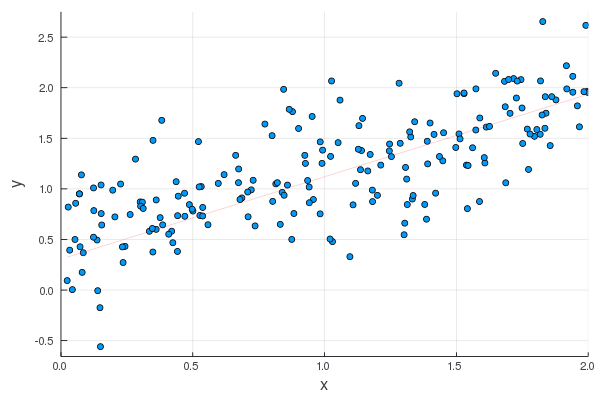

```julia
data = [X Y]

idx = sample(axes(data, 1), 200) #lets sample 200 cases
mysample = data[idx, :]

x = mysample[:, 1]
y = mysample[:, 2]

mu, Sn, phi = getPosterior(y, x, .4, .7, .5^2) # Additionally we are going to return the phi design matrix for convenience.
                                                # Also, we are defining a variance for our prior of .5^2 and the mean of our prior to be .7
                                                # You can change the mean of the prior and the sample size to see how that affect the estimation.

# lets plot our sample
plt = plot(x, y, xlab = "x", ylab = "y", seriestype = :scatter, xlims = (0, 2), legend = false)

# and now lets pick 300 random posible regression lines from our posterior and animate them
@gif for i = 1:300
    w = rand(MvNormal(mu, Sn))
    plot!(plt, x, phi * w, linecolor = :red, linealpha = 0.2)
end every 2
```

We can also get a nice contour plot of the estimated parameters

```julia
w = rand(MvNormal(mu, Sn), 10000)
histogram2d(w[1, :], w[2, :], nbins=50)
```

[figure not shown]

Our visual quick and dirty estimation above work decently. How does it compare with a real, well implemented package for bayesian inference?

```julia
using Turing
using StatsPlots

@model function gdemo()
    x ~ MvNormal(mu, Sn) #in the case of Turing.jl we need to specify a model with a macro, but that model can also be just our posterior distribution.
end
```

```
gdemo (generic function with 1 method)
```

```julia
c1 = sample(gdemo(), HMC(0.1, 1), 10000)
# Plot results
plot(c1)
```

```
Sampling: 100%|█████████████████████████████████████████| Time: 0:00:00
```

[figure not shown]

```julia
c1
```

```
Chains MCMC chain (10000×11×1 Array{Float64,3}):

Iterations        = 1:10000
Thinning interval = 1
Chains            = 1
Samples per chain = 10000
parameters        = x[1], x[2]
internals         = acceptance_rate, hamiltonian_energy, hamiltonian_energy_error, is_accept, log_density, lp, n_steps, nom_step_size, step_size

Summary Statistics
  parameters      mean       std   naive_se      mcse        ess      rhat
      Symbol   Float64   Float64    Float64   Float64    Float64   Float64

        x[1]    0.5572    0.2106     0.0021    0.0107   266.9725    1.0030
        x[2]    0.6613    0.1826     0.0018    0.0091   287.3646    1.0026

Quantiles
  parameters      2.5%     25.0%     50.0%     75.0%     97.5%
      Symbol   Float64   Float64   Float64   Float64   Float64

        x[1]    0.1330    0.4200    0.5560    0.6944    0.9731
        x[2]    0.2916    0.5437    0.6630    0.7799    1.0155
```

Turing.jl use MCMC samplers to sample the posterior, which is the appropiate way to get the distribution of the posterior by numerical ways. We did a random sampling to plot the results, but since our posterior was a Gaussian, the sampling looked like it worked fine, but my intuition is that we just got lucky. Anyway, the summary above show that we did actually a good job with our posterior. We did got an decent aproximation to the real parameters of the population. Eventually, in future notebooks, I'll try to figure out a way to do the same analysis, but with unknown variance.

# References

Yuan, Y., & MacKinnon, D. P. (2009). Bayesian mediation analysis. Psychological methods, 14(4), 301.

Prediction of homing pigeon flight paths using Gaussian processes. (2010). [PhD thesis]. Oxford University, UK.